# Ecological Adaptation Drives Wood Frog Population Divergence in Life History Traits

R13B42015

2024-12-15

### Abstract

- **Objective:** This study investigates the ecological and evolutionary processes that drive population divergence in wood frogs (*Lithobates sylvaticus*), focusing on key life history traits such as hatching date, morphological characteristics, development rate, and survival strategies.
- **Methods:** This study analyzed a dataset of multiple wood frog populations, using statistical methods including linear regression, MANOVA, PCA, and GLM to explore the relationships between these traits and environmental factors.
- **Results:** Significant variation was observed in hatching dates, morphological characteristics, and survival strategies across populations. Temperature and larval density were found to jointly influence tadpole mortality.
- **Conclusion:** The findings suggest that wood frogs exhibit adaptive responses to local environmental conditions, which may have important implications for their conservation and management in the face of ongoing environmental changes.

### Introduction

- **Background:** Wood frogs (*Lithobates sylvaticus*) are a model species for studying ecological adaptation and population divergence due to their wide distribution and significant variation in life history traits across different populations.
- **Importance of Study:** Understanding the drivers of this variation is crucial for predicting how populations may respond to environmental changes and for developing effective conservation strategies.
- **Research Questions:**
  - How do geographic and environmental factors influence hatching dates across wood frog populations?
  - Are there significant differences in morphological characteristics (e.g., SVL, femur length, weight) between populations?
  - Do different populations exhibit distinct survival strategies, as indicated by development rates and other traits?
  - How do temperature and larval density jointly affect tadpole mortality?

### Methods and results

#### Data Collection

Click the button below to download the dataset.

Download Ecological adaptation drives wood frog population divergence in life history traits.xlsx

- **Dataset:** The dataset “Ecological adaptation drives wood frog population divergence in life history traits.xlsx” contains information on various life history traits and environmental variables for multiple wood frog populations.
- **Variables:** Key variables include hatching date, morphological measurements (SVL, femur length, weight), development rate, temperature, larval density, and mortality.

#### Library

```r
library(readxl)
library(dplyr)
library(ggplot2)
library(leaflet)
library(factoextra)
library(lme4)
library(MASS)
library(car)
library(lmerTest)
library(survival)
```

#### Data Preprocessing

- **Column Names:** Column names were cleaned to remove spaces and parentheses for easier data manipulation.
- **Color Assignment:** Unique colors were assigned to each population for visualization purposes.

```r
### read dataset
xlsx_file<- "Ecological adaptation drives wood frog population divergence in life history traits.xlsx"
frog_path<- paste0("C:\\Users\\user\\Desktop\\frogs\\", xlsx_file)
frogs<- as.data.frame(read_xlsx(frog_path))
colnames(frogs)<- gsub(" ", ".", colnames(frogs))
colnames(frogs)<- gsub("\\(|\\)", "", colnames(frogs))
head(frogs)
```

```
##   Population.Name latitude longitude ENM.score Hatching.Date Frog.ID
## 1       Amicalola 34.55582 -84.25068 0.3838083    2012-02-01      A1
## 2       Amicalola 34.55582 -84.25068 0.3838083    2012-02-01     A10
## 3       Amicalola 34.55582 -84.25068 0.3838083    2012-02-01     A11
## 4       Amicalola 34.55582 -84.25068 0.3838083    2012-02-01     A12
## 5       Amicalola 34.55582 -84.25068 0.3838083    2012-02-01     A13
## 6       Amicalola 34.55582 -84.25068 0.3838083    2012-02-01     A14
##   larval.density.treatment larval.period.temperature.C Date.of.metamorphosis
## 1                      Low                    15.22881            2012-04-16
## 2                      Low                    15.26230            2012-04-18
## 3                      Low                    15.26230            2012-04-18
## 4                      Low                    15.26230            2012-04-18
## 5                      Low                    15.26230            2012-04-18
## 6                      Low                    15.26230            2012-04-18
##   Larval.period.days Weight.g SVL.mm Femur.length.mm Date.of.death Mortality
## 1                 75    0.593  17.24            9.24          <NA>         0
## 2                 77    0.586  18.25            8.62         41078         1
## 3                 77    0.556  18.17            7.79          <NA>         0
## 4                 77    0.453  17.30            9.31         41078         1
## 5                 77    0.512  17.72            8.86         41078         1
## 6                 77    0.416  15.48            7.81          <NA>         0
##   Days.to.death
## 1            90
## 2            61
## 3            90
## 4            61
## 5            61
## 6            90
```

```r
# Extract unique population names
population <- unique(frogs$Population.Name)
population
```

```
##  [1] "Amicalola"       "Cheaha"          "Caesar's Creek"  "Craig's Creek"
##  [5] "Caney Fork"      "East Fork"       "Oregon Ridge"    "Powdermill"
##  [9] "State College"   "Snodgrass"       "Sugar Hollow"    "Thompson Hollow"
## [13] "Zach's Way"
```

```r
# Define color list for populations
col_list<- c("red","#00FF00", "blue", "cyan", "magenta", "yellow2", "orange",
             "purple", "brown", "pink", "gray", "#008080", "black")
# Assign colors to each population
population_no<- 1
for (population_no in 1:length(population))
{
  frogs[frogs$Population.Name == population[population_no],"col"]<- col_list[population_no]
}
```

#### Distrubution of frogs

```r
### mapping
leaflet(frogs) %>%
  addProviderTiles(providers$CartoDB.Positron) %>%
  addCircles(
    lng = ~longitude,
    lat = ~latitude,
    radius = 500,
    color = frogs$col,
    fillOpacity = 0.5,
    stroke = TRUE,
    weight = 10,
    popup = ~paste(Frog.ID)
  ) %>%
  addScaleBar(position = "bottomright") %>%
  addMeasure() %>%
  addControl("<strong>Species Distribution Map</strong>", position = "topright",
             className = "leaflet-control-custom")%>%
  addLegend(
    position = "bottomleft",
    colors = col_list,
    labels = population,
    title = "Population Groups",
    opacity = 0.7)
```

[interactive chart not shown]

#### Statistical Analyses

##### 1. Factors Influencing Hatching Date

```r
# Analyze factors influencing hatching date
# Convert Hatching.Date to Date type
frogs$Hatching.Date <- as.Date(frogs$Hatching.Date, format = "%m/%d/%y")

# Extract month as a proxy for hatching time
frogs$hatch_month <- as.numeric(format(frogs$Hatching.Date, "%m"))

# set custom_theme
custom_theme <- theme(
  panel.background = element_blank(),  # Remove panel background
  legend.position = "right",           # Position the legend on the right
  panel.border = element_rect(color = "black", fill = NA, size = 0.5)  # Keep the border
  )
```

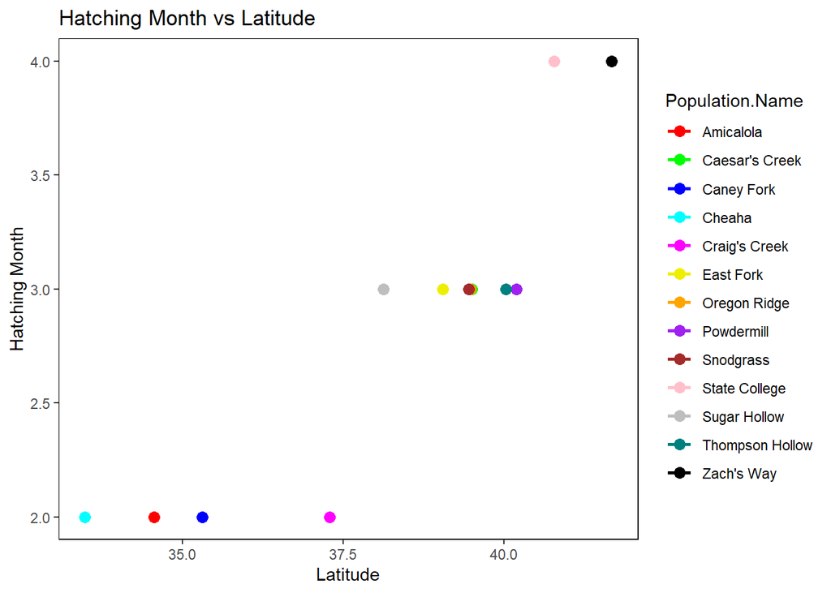

```r
# Plot hatching date vs latitude
ggplot(frogs, aes(x = latitude, y = hatch_month,color = Population.Name)) +
  geom_point(shape = 16, size = 3) +
  geom_smooth(method = "lm", se = FALSE) +
  scale_color_manual(values = col_list) +
  labs(title = "Hatching Month vs Latitude", x = "Latitude", y = "Hatching Month")+
  custom_theme
```

```r
# Perform linear regression analysis
model_hatch_lat <- lm(hatch_month ~ latitude, data = frogs)
summary(model_hatch_lat)
```

```
##
## Call:
## lm(formula = hatch_month ~ latitude, data = frogs)
##
## Residuals:
##     Min      1Q  Median      3Q     Max
## -0.5514 -0.2256 -0.0657  0.2419  0.5902
##
## Coefficients:
##              Estimate Std. Error t value Pr(>|t|)
## (Intercept) -6.616082   0.150720  -43.90   <2e-16 ***
## latitude     0.245860   0.003923   62.66   <2e-16 ***
## ---
## Signif. codes:  0 '***' 0.001 '**' 0.01 '*' 0.05 '.' 0.1 ' ' 1
##
## Residual standard error: 0.3012 on 1015 degrees of freedom
## Multiple R-squared:  0.7946, Adjusted R-squared:  0.7944
## F-statistic:  3927 on 1 and 1015 DF,  p-value: < 2.2e-16
```

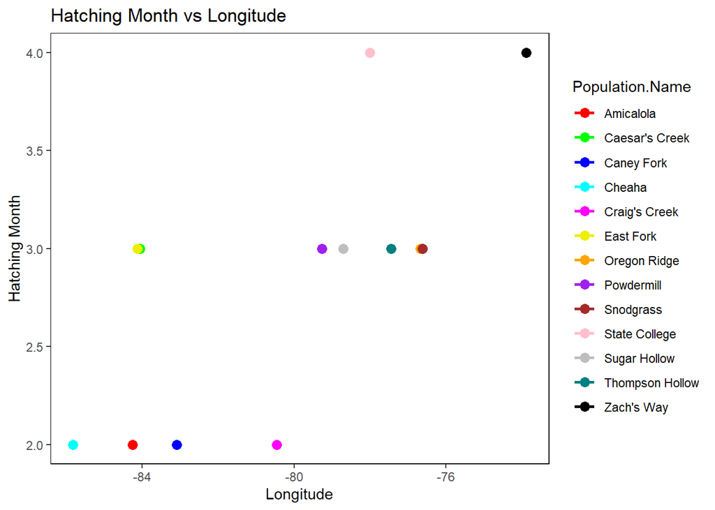

```r
# Plot hatching date vs longitude
ggplot(frogs, aes(x = longitude, y = hatch_month,color = Population.Name)) +
  geom_point(shape = 16, size = 3) +
  geom_smooth(method = "lm", se = FALSE) +
  scale_color_manual(values = col_list) +
  labs(title = "Hatching Month vs Longitude", x = "Longitude", y = "Hatching Month")+
  custom_theme
```

```r
# Perform linear regression analysis
model_hatch_lon <- lm(hatch_month ~ longitude, data = frogs)
summary(model_hatch_lon)
```

```
##
## Call:
## lm(formula = hatch_month ~ longitude, data = frogs)
##
## Residuals:
##     Min      1Q  Median      3Q     Max
## -0.7827 -0.2854 -0.1774  0.3560  0.8958
##
## Coefficients:
##              Estimate Std. Error t value Pr(>|t|)
## (Intercept) 13.335663   0.349957   38.11   <2e-16 ***
## longitude    0.131160   0.004357   30.11   <2e-16 ***
## ---
## Signif. codes:  0 '***' 0.001 '**' 0.01 '*' 0.05 '.' 0.1 ' ' 1
##
## Residual standard error: 0.4831 on 1015 degrees of freedom
## Multiple R-squared:  0.4717, Adjusted R-squared:  0.4712
## F-statistic: 906.3 on 1 and 1015 DF,  p-value: < 2.2e-16
```

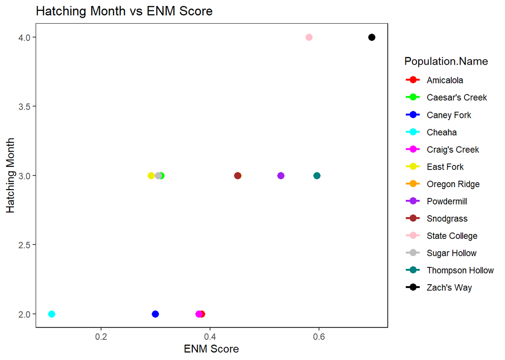

```r
# Plot hatching date vs ENM score
ggplot(frogs, aes(x = ENM.score, y = hatch_month,color = Population.Name)) +
  geom_point(shape = 16, size = 3) +
  geom_smooth(method = "lm", se = FALSE) +
  scale_color_manual(values = col_list) +
  labs(title = "Hatching Month vs ENM Score", x = "ENM Score", y = "Hatching Month")+
  custom_theme
```

```r
# Perform linear regression analysis
model_hatch_enm <- lm(hatch_month ~ ENM.score, data = frogs)
summary(model_hatch_enm)
```

```
##
## Call:
## lm(formula = hatch_month ~ ENM.score, data = frogs)
##
## Residuals:
##      Min       1Q   Median       3Q      Max
## -0.69648 -0.43072  0.09319  0.53580  0.68326
##
## Coefficients:
##             Estimate Std. Error t value Pr(>|t|)
## (Intercept)  1.49297    0.04474   33.37   <2e-16 ***
## ENM.score    3.13571    0.10044   31.22   <2e-16 ***
## ---
## Signif. codes:  0 '***' 0.001 '**' 0.01 '*' 0.05 '.' 0.1 ' ' 1
##
## Residual standard error: 0.4747 on 1015 degrees of freedom
## Multiple R-squared:  0.4898, Adjusted R-squared:  0.4893
## F-statistic: 974.6 on 1 and 1015 DF,  p-value: < 2.2e-16
```

##### 2. Comparison of Morphological Characteristics Across Populations

- **MANOVA:** A multivariate analysis of variance (MANOVA) was conducted to compare morphological traits (SVL, femur length, weight) across populations.
- **ANOVA:** Follow-up ANOVA tests were performed for individual traits to identify specific patterns of divergence.
- **Visualization:** Boxplots were used to visualize the distribution of morphological traits across populations.

```r
# Compare morphological characteristics across different populations
# Use MANOVA to compare morphological features across populations
manova_result <- manova(cbind(SVL.mm, Femur.length.mm, Weight.g) ~ Population.Name, data = frogs)
summary(manova_result, test = "Pillai")
```

```
##                   Df  Pillai approx F num Df den Df    Pr(>F)
## Population.Name   12 0.34483   10.866     36   3012 < 2.2e-16 ***
## Residuals       1004
## ---
## Signif. codes:  0 '***' 0.001 '**' 0.01 '*' 0.05 '.' 0.1 ' ' 1
```

```r
# If MANOVA shows significant differences, perform ANOVA for individual variables
anova_SVL.mm <- aov(SVL.mm ~ Population.Name, data = frogs)
summary(anova_SVL.mm)
```

```
##                   Df Sum Sq Mean Sq F value Pr(>F)
## Population.Name   12  409.3   34.11   12.15 <2e-16 ***
## Residuals       1004 2817.8    2.81
## ---
## Signif. codes:  0 '***' 0.001 '**' 0.01 '*' 0.05 '.' 0.1 ' ' 1
```

```r
anova_femur <- aov(Femur.length.mm ~ Population.Name, data = frogs)
summary(anova_femur)
```

```
##                   Df Sum Sq Mean Sq F value Pr(>F)
## Population.Name   12  234.2  19.517   14.43 <2e-16 ***
## Residuals       1004 1357.8   1.352
## ---
## Signif. codes:  0 '***' 0.001 '**' 0.01 '*' 0.05 '.' 0.1 ' ' 1
```

```r
anova_Weight.g <- aov(Weight.g ~ Population.Name, data = frogs)
summary(anova_Weight.g)
```

```
##                   Df Sum Sq Mean Sq F value Pr(>F)
## Population.Name   12  3.917  0.3264   16.29 <2e-16 ***
## Residuals       1004 20.120  0.0200
## ---
## Signif. codes:  0 '***' 0.001 '**' 0.01 '*' 0.05 '.' 0.1 ' ' 1
```

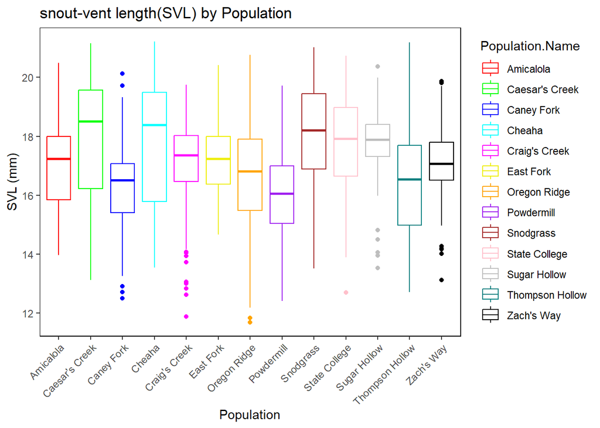

```r
# Visualize morphological differences across populations
ggplot(frogs, aes(x = Population.Name, y = SVL.mm, color = Population.Name)) +
  geom_boxplot() +
  labs(title = "snout-vent length(SVL) by Population", x = "Population", y = "SVL (mm)")+
  scale_color_manual(values = col_list) +
  theme(axis.text.x = element_text(angle = 45, hjust = 1))+
  custom_theme
```

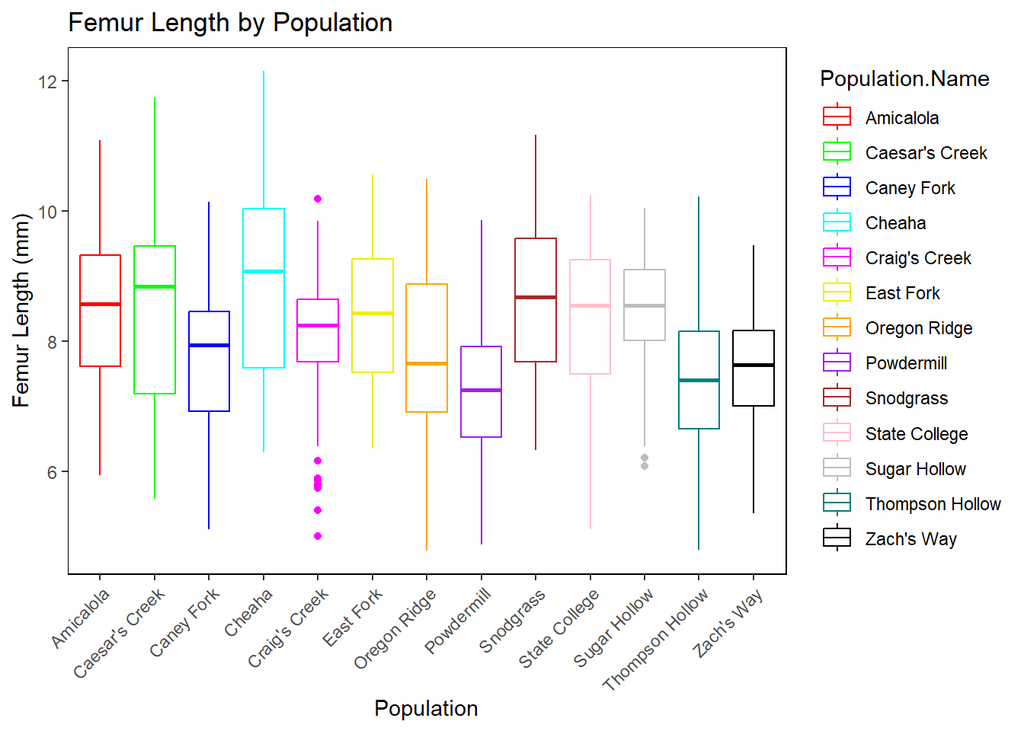

```r
ggplot(frogs, aes(x = Population.Name, y = Femur.length.mm, color = Population.Name)) +
  geom_boxplot() +
  labs(title = "Femur Length by Population", x = "Population", y = "Femur Length (mm)")+
  scale_color_manual(values = col_list) +
  theme(axis.text.x = element_text(angle = 45, hjust = 1))+
  custom_theme
```

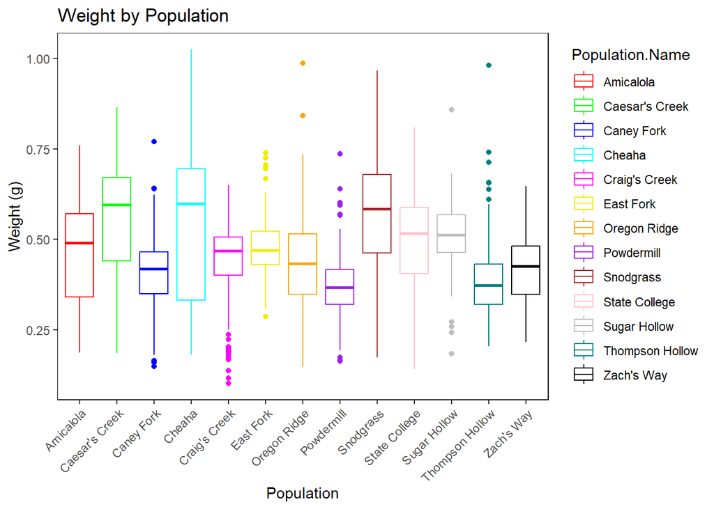

```r
ggplot(frogs, aes(x = Population.Name, y = Weight.g, color = Population.Name)) +
  geom_boxplot() +
  labs(title = "Weight by Population", x = "Population", y = "Weight (g)")+
  scale_color_manual(values = col_list) +
  theme(axis.text.x = element_text(angle = 45, hjust = 1))+
  custom_theme
```

- **MANOVA:** The MANOVA results indicated significant differences in morphological traits across populations (p < 0.05).
- **ANOVA:**
  - **SVL:** Significant differences in SVL were observed between populations (p < 0.05). **Femur Length:** Significant differences in femur length were observed between populations (p < 0.05).
  - **Weight:** Significant differences in weight were observed between populations (p < 0.05).
- **Visualization:** Boxplots revealed that some populations had consistently larger or smaller body sizes compared to others.

##### 3. Investigation of Survival Strategies

- **PCA:** Principal component analysis (PCA) was used to explore the variation in survival-related traits (development rate, SVL, femur length, weight, larval period) among populations.
- **Visualization:** A PCA biplot was created to visualize the relationships between populations and traits.

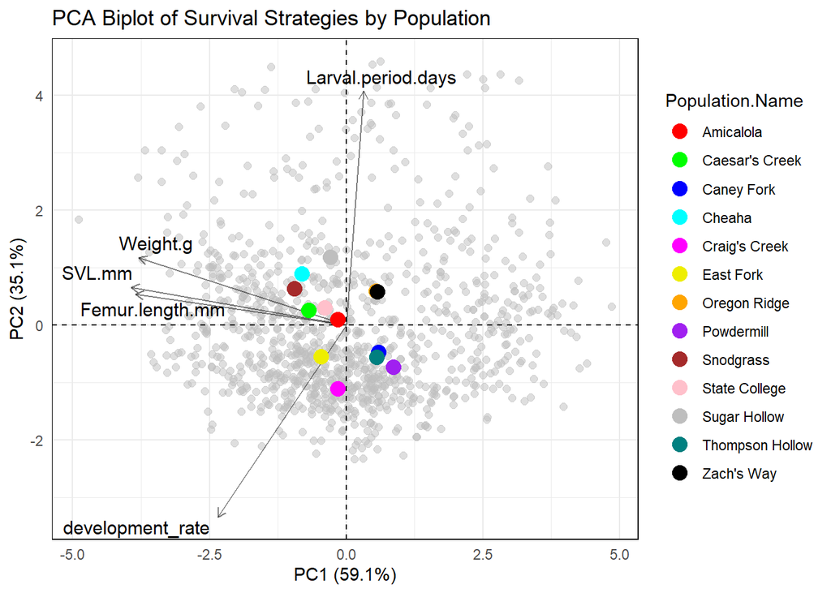

```r
# Do different populations exhibit different survival strategies?
# Calculate development rate (SVL growth per day)
if (!"development_rate" %in% colnames(frogs)) {
  frogs$development_rate <- with(frogs, SVL.mm / Larval.period.days)
}

# Select columns for PCA
pca_data <- frogs %>%
  dplyr::select(Population.Name, development_rate, Weight.g, SVL.mm, Femur.length.mm, Larval.period.days)

# Remove rows with missing values
pca_data_clean <- na.omit(pca_data)

# Ensure "Population.Name" is a factor
pca_data_clean$Population.Name <- as.factor(pca_data_clean$Population.Name)

# Perform PCA, excluding non-numeric columns (e.g., Population.Name)
pca_result <- prcomp(pca_data_clean %>% dplyr::select(-Population.Name), scale. = TRUE)

# Extract scores and loadings
pca_scores <- as.data.frame(pca_result$x)
pca_scores$Population.Name <- pca_data_clean$Population.Name
pca_loadings <- as.data.frame(pca_result$rotation)

# Calculate the mean score for each population to reduce clutter
population_means <- pca_scores %>%
  group_by(Population.Name) %>%
  summarise(across(starts_with("PC"), mean))

# Plot PCA biplot with simplified points and selected variables
fviz_pca_biplot(pca_result,
                col.ind = "gray",  # Individuals in gray (less prominent)
                col.var = "black", # Variables in black
                palette = "jco",   # Color palette for populations
                addEllipses = FALSE, # No ellipses to reduce clutter
                label = "var",     # Label variables
                repel = TRUE,      # Avoid overlapping labels
                geom = "point",    # Only show points for individuals
                pointsize = 2,     # Smaller points for individuals
                alpha = 0.5,       # Transparency of individual points
                title = "PCA Biplot of Survival Strategies by Population",
                xlab = paste0("PC1 (", round(summary(pca_result)$importance[2, 1] * 100, 1), "%)"),
                ylab = paste0("PC2 (", round(summary(pca_result)$importance[2, 2] * 100, 1), "%)")
) +
  # Add population means as colored points
  geom_point(data = population_means, aes(x = PC1, y = PC2, color = Population.Name), size = 4, alpha = 1) +
  theme_minimal() +
  scale_color_manual(values = col_list) +
  theme(legend.position = "right")+
  custom_theme
```

- **PCA:** The PCA biplot showed that the first two principal components explained a large proportion of the variance in survival-related traits. Different populations clustered together based on their trait profiles, suggesting distinct survival strategies.
- **Development Rate:** Populations with higher development rates tended to have shorter larval periods, indicating a potential trade-off between growth rate and time to metamorphosis.

##### 4. Effects of Temperature and Larval Density on Mortality

```r
# Does temperature and larval density jointly affect tadpole mortality?
# Create a binary variable indicating whether the individual died
frogs$dead <- ifelse(frogs$Mortality == 1, 1, 0)

# Use GLM to analyze the effect of temperature and density on mortality
glm_death <- glm(dead ~ larval.period.temperature.C + larval.density.treatment, data = frogs, family = binomial)

# Check model summary
summary(glm_death)
```

```
##
## Call:
## glm(formula = dead ~ larval.period.temperature.C + larval.density.treatment,
##     family = binomial, data = frogs)
##
## Coefficients:
##                             Estimate Std. Error z value Pr(>|z|)
## (Intercept)                 -34.7561     7.9262  -4.385 1.16e-05 ***
## larval.period.temperature.C   2.3055     0.5251   4.391 1.13e-05 ***
## larval.density.treatmentLow  -1.1406     0.1718  -6.640 3.15e-11 ***
## ---
## Signif. codes:  0 '***' 0.001 '**' 0.01 '*' 0.05 '.' 0.1 ' ' 1
##
## (Dispersion parameter for binomial family taken to be 1)
##
##     Null deviance: 1302.8  on 1016  degrees of freedom
## Residual deviance: 1250.5  on 1014  degrees of freedom
## AIC: 1256.5
##
## Number of Fisher Scoring iterations: 4
```

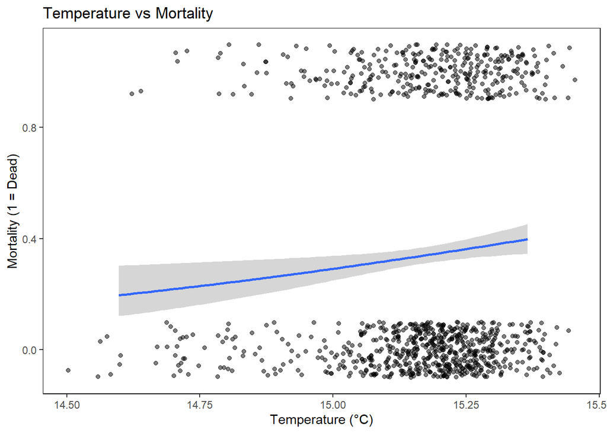

```r
# Plot temperature vs mortality
ggplot(frogs, aes(x = larval.period.temperature.C, y = dead)) +
  geom_jitter(width = 0.1, height = 0.1, alpha = 0.5) +
  geom_smooth(method = "glm", method.args = list(family = binomial), se = T) +
  labs(title = "Temperature vs Mortality", x = "Temperature (°C)", y = "Mortality (1 = Dead)")+
  custom_theme
```

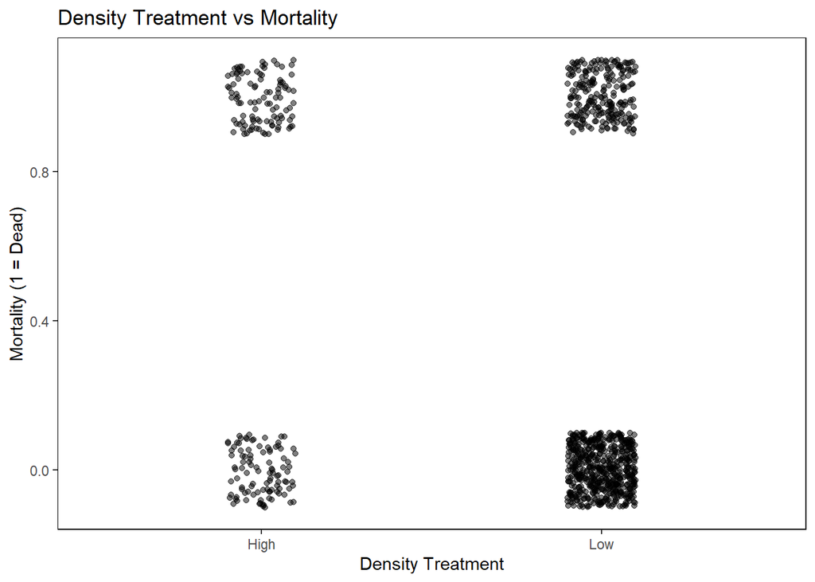

```r
# Plot density treatment vs mortality
ggplot(frogs, aes(x = larval.density.treatment, y = dead)) +
  geom_jitter(width = 0.1, height = 0.1, alpha = 0.5) +
  geom_smooth(method = "glm", method.args = list(family = binomial), se = T) +
  labs(title = "Density Treatment vs Mortality", x = "Density Treatment", y = "Mortality (1 = Dead)")+
  custom_theme
```

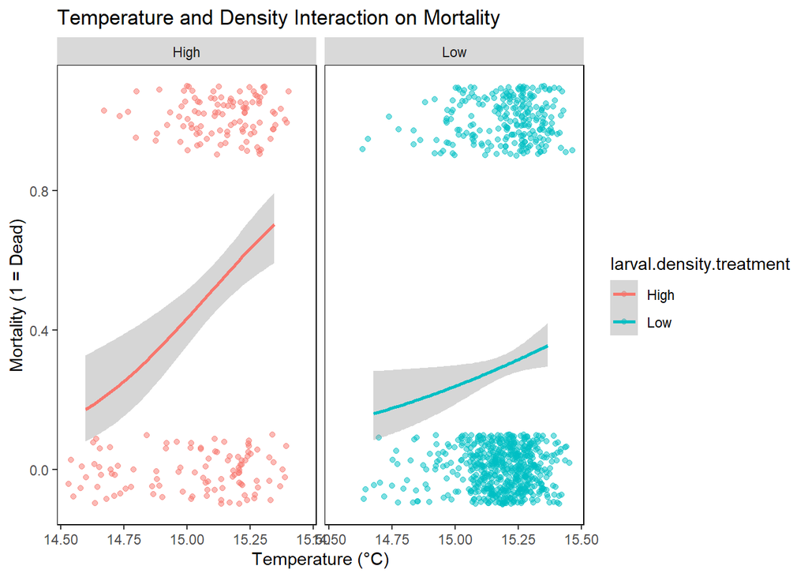

```r
# Plot interaction between temperature and density on mortality
ggplot(frogs, aes(x = larval.period.temperature.C, y = dead, color = larval.density.treatment)) +
  geom_jitter(width = 0.1, height = 0.1, alpha = 0.5) +
  geom_smooth(method = "glm", method.args = list(family = binomial), se = T) +
  labs(title = "Temperature and Density Interaction on Mortality", x = "Temperature (°C)", y = "Mortality (1 = Dead)") +
  facet_wrap(~ larval.density.treatment)+
  custom_theme
```

### Discussion/Conclusion

- **Key Findings:**
  - Geographic and environmental factors play a crucial role in shaping the timing of hatching in wood frogs.
  - Morphological characteristics vary significantly across populations, likely reflecting adaptations to local environmental conditions.
  - Different populations exhibit distinct survival strategies, as evidenced by differences in development rates and other traits.
  - Temperature and larval density jointly influence tadpole mortality, highlighting the importance of both abiotic and biotic factors in early life stages.
- **Implications:**
  - The observed patterns of population divergence suggest that wood frogs are capable of rapid adaptation to local environmental conditions.
  - Understanding these adaptive responses can inform conservation efforts, particularly in the context of climate change and habitat alteration.
  - Future research should focus on identifying the genetic mechanisms underlying these adaptive traits and exploring how they may evolve in response to ongoing environmental changes.
- **Limitations:**
  - The dataset may not capture all relevant environmental variables, which could limit the generalizability of the findings.
  - Further studies with larger sample sizes and more detailed environmental data would provide a more comprehensive understanding of the factors driving population divergence.
- **Future Directions:**
  - Investigate the genetic basis of adaptive traits in wood frogs.
  - Conduct experimental studies to test the causal relationships between environmental factors and life history traits.
  - Explore the long-term impacts of climate change on wood frog populations and their ability to adapt.

### References

- *Le Sage, E. H., Duncan, S. I., Seaborn, T., Cundiff, J., Rissler, L. J., & Crespi, E. J. (2021).* Ecological adaptation drives wood frog population divergence in life history traits. Heredity, 126(7), 790–804. https://doi.org/10.1038/s41437-021-00409-w